# Data Visualization

## Line Graphs: One Independent Variable

*How to cure hiccups?*

Participants:

- 15 hiccup sufferers

Each tries four interventions (in random order):

- Baseline
- Tongue-pulling manoeuvres
- Massage of the carotid artery
- Digital rectal massage

Outcome measure

- The number of hiccups in the minute after each procedure

We can then create the line graph by executing the following commands:

```r
line <- ggplot(hiccups, aes(Intervention_Factor, Hiccups))
```

```r
line + stat_summary(fun.y = mean, geom = "point") +
stat_summary(fun.y = mean, geom = "line", aes(group = 1), colour = "Red",
    linetype = "dashed") + stat_summary(fun.data = mean_cl_boot, geom = "errorbar",
    width = 0.2) + labs(x = "Intervention", y = "Mean Number of Hiccups")
```

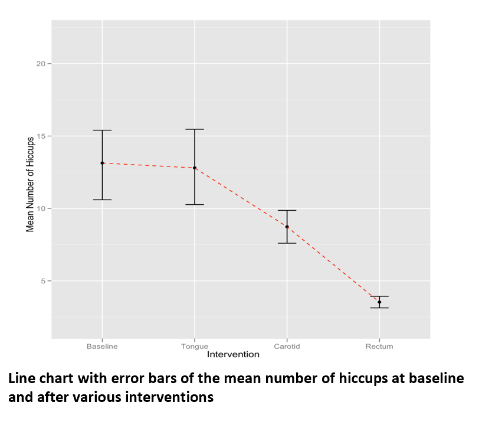

## Line Graphs for Several Independent Variables

*Is text-messaging bad for your grammar?*

Participants:

- 50 children

Children split into two groups:

- Text-messaging allowed
- Text-messaging forbidden

Each child measures at two points in time: * Baseline * 6 months later

Outcome measure * Percentage score on a grammar test

We can then create the line graph by executing the following commands:

```r
line <- ggplot(textMessages, aes(Time, Grammar_Score, colour = Group))
```

```r
line + stat_summary(fun.y = mean, geom = "point") + stat_summary(fun.y = mean,
    geom = "line", aes(group = Group)) + stat_summary(fun.data = mean_cl_boot,
    geom = "errorbar", width = 0.2) + labs(x = "Time", y = "Mean Grammar Score",
    colour = "Group")
```

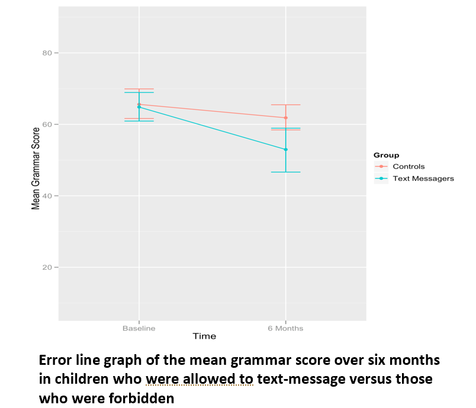